# A3: SPL Library Checkouts

### Introduction

The data that I will be analyzing is from the Seattle Public Library. My main focus will be on analyzing the data of the types of books people have checked out during the years of 2020-2022

### Summary Information

I want to try and answer these following questions:

How did COVID affect the physical and digital checkout with books in 2020? - I will be first grouping the physical and digital types of books within a category, then I will calculate the total checkouts between the both within the year of 2020 by months, then I will plot the data with two line plots

Who was the most popular author between 2020-2022? - I first grouped all the authors by the total amount of checkouts they have. Then I proceeded to sort the data to see who was in the top between 2020-2022. Then I only grabbed top 10 and plot the data with a column graph.

What top 5 types of books was the most popular during 2020-2022? - I first filtered the data to only material types, then I sorted the data from the highest to lowest checkouts. To find the top 5 I grabbed only the first 5 within the sorted data then I plotted it in a piechart!

Calculated values: 1. Physical checkouts in 2020’s months 2. Digital checkouts in 2020’s months 3. All the author’s checkouts in total 4. Top ten authors within 2020-2022 5. Top five most checked out material type books within 2020-2022

### The Dataset

- Who collected/published the data?
  - Seattle Public Library published the data.
- What are the parameters of the data (dates, number of checkouts, kinds of books, etc.)?
  - Usage class, Checkout types, Material types, Check out year and month, number of checkouts, title, ISBN, Author, Subjects, Publisher, and publication year
- How was the data collected or generated?
  - The data was collected.
- Why was the data collected?
  - To determines the checkout data of the library.
- What, if any, ethical questions do you need to consider when working with this data?
  - There aren’t really ethical questions dealing with this data in relation to my research questions and curiosity.
- What are possible limitations or problems with this data? (at least 200 words)
  - The possible limitation is that if there are trends on the data of certain books, there won’t be a big affect considering it’s only from year 2020 to 2023. Another would be that, when looking through the data, we see that some ISBN numbers don’t exists or that they don’t have any which can mean that some books might be checked out improperly because they usually would have to scan check the books. There also might be some human errors when checking out the books.

### Digital vs Physical checkouts during 2020.

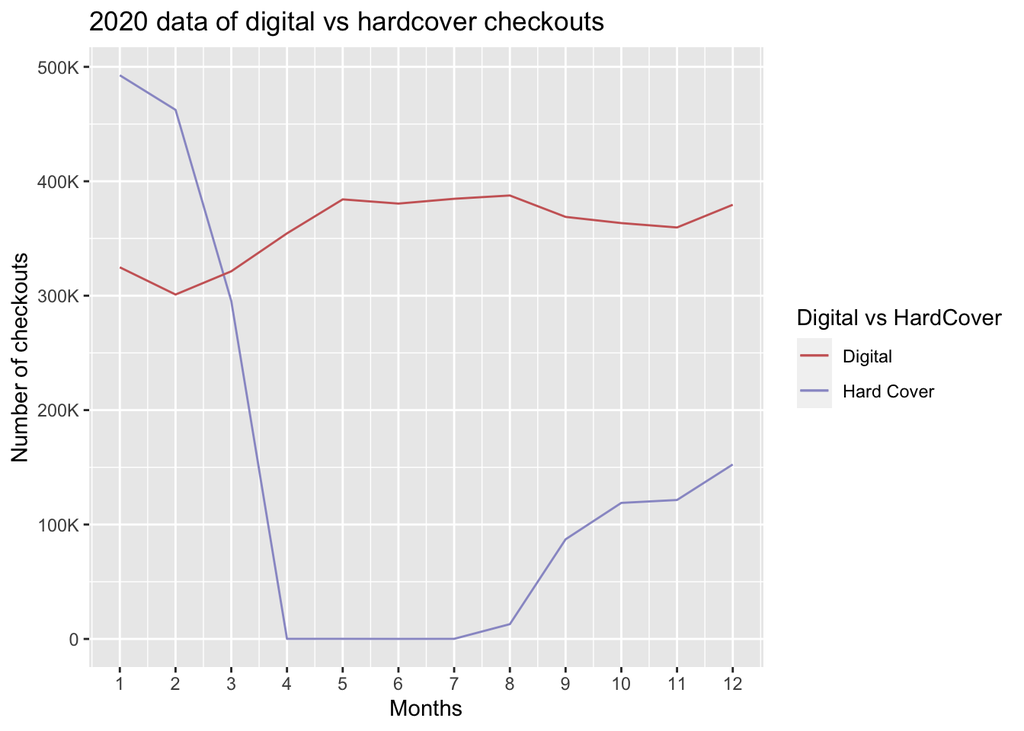

These two charts is being presented to explore the changes between the digital and physical checkouts especially during the rise of COVID during 2020.

As we can see that the hardcover checkouts dropped and digital checkouts was on a rise. This pattern made sense for book checkouts because during the pandemic the lockdown was strongly affecting the types of checkouts people were doing.

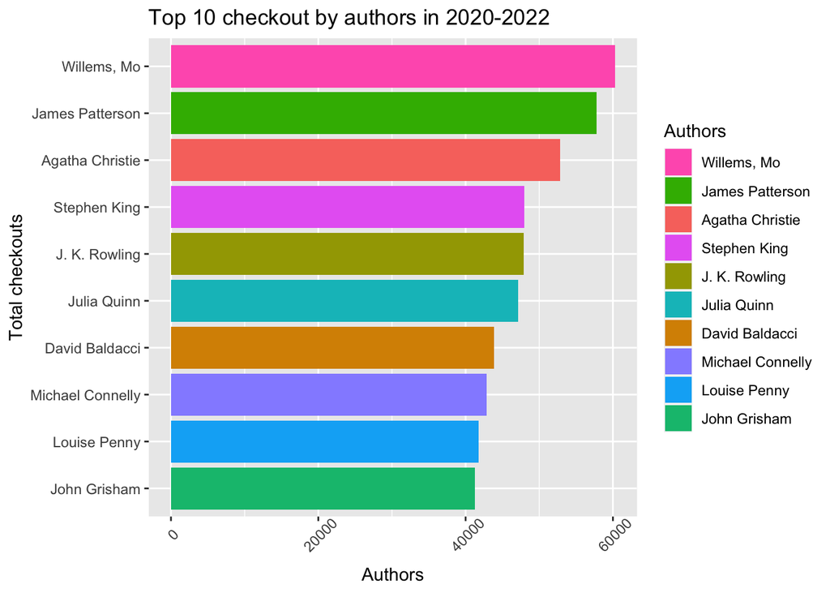

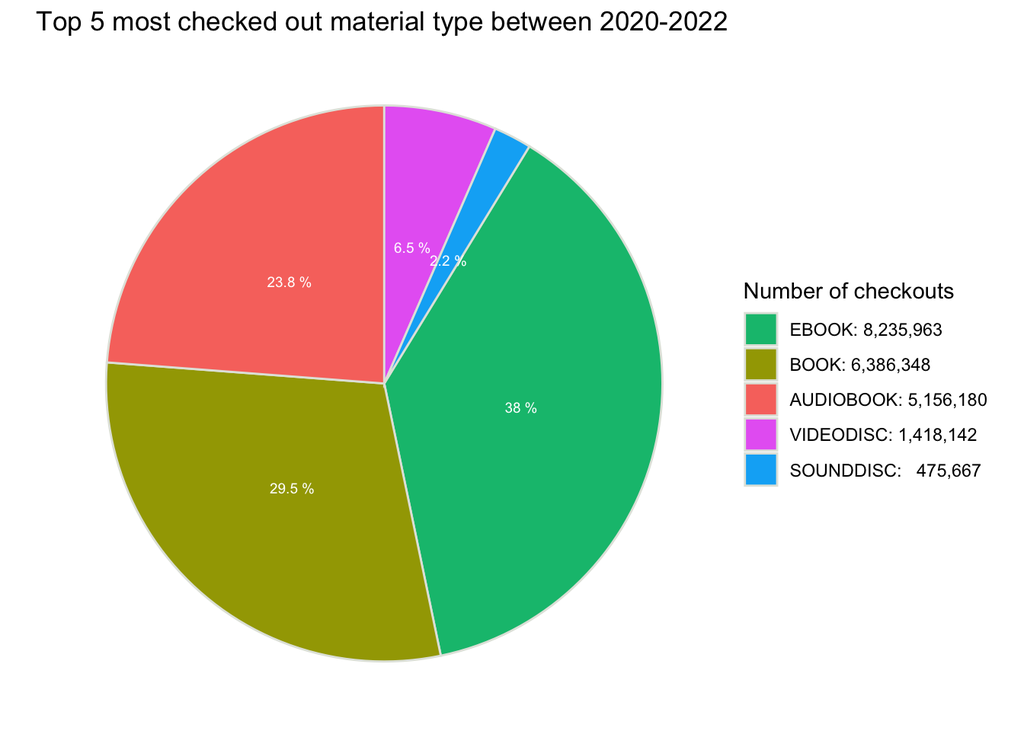